# Seaborn

Seaborn é uma biblioteca de visualização de dados para Python baseada no matplotlib. Ele fornece uma interface de alto nível para desenhar gráficos estatísticos.

# Importanto Base de Dados

Importando Bibliotecas

```python
import pandas as pd
import seaborn as sns
```

Carregando base de dados

```python
dados = pd.read_csv('tips.csv')
dados.head()
```

|  | total_bill | tip | dessert | day | time | size |
| --- | --- | --- | --- | --- | --- | --- |
| 0 | 16.99 | 1.01 | No | Sun | Dinner | 2 |
| 1 | 10.34 | 1.66 | No | Sun | Dinner | 3 |
| 2 | 21.01 | 3.50 | No | Sun | Dinner | 3 |
| 3 | 23.68 | 3.31 | No | Sun | Dinner | 2 |
| 4 | 24.59 | 3.61 | No | Sun | Dinner | 4 |

Nos basearemos em gorjetas e sabemos aplicamos 10% do valor total da conta no Brasil, enquanto em demais países os clientes têm costume de dar caixinha livremente, sem uma porcentagem específica. Com isso, analisaremos diversas influências sobre este valor conforme citamos anteriormente.

Veremos que há 244 linhas com índice numérico e 6 colunas: *"total_bill"*, *"tip"*, *"dessert"*, *"day"*, *"time"* e *"size"*. Em um primeiro momento, entenderemos do que se tratam cada uma.

```
total_bill: valor total da conta paga pelo cliente
tip: valor da gorjeta em si
dessert: se a pessoa pediu sobremesa ou não
day: dia da semana
time: horário de almoço ou horário de jantar
size: quantidade de clientes na mesa
```

# Análise 1 - Valor da conta e gorjeta

Verificando quais colunas existem no DataFrame

```python
dados.columns
```

```
Index(['total_bill', 'tip', 'dessert', 'day', 'time', 'size'], dtype='object')
```

Os gráficos de dispersão ou Scatter plot são representações gráficas do relacionamento entre duas variáveis numéricas. O Scatter plot utiliza pontos para representar essa relação, cada ponto representa o valor de uma variável no eixo horizontal e o valor de outra variável no eixo vertical.

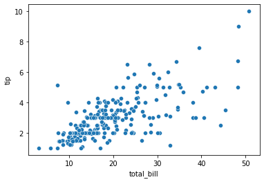

```python
tip_value = sns.scatterplot(x='total_bill', y='tip', data=dados)
```

As funções do seaborn `set_palette()` e `set_style()` são responsaveis por mudar a aparência dos graficos o `set_palette()` por definir as paleta de cores dos graficos e a `set_style()`, o estilo.

```python
sns.set_palette('Accent')
sns.set_style('darkgrid')
```

O grafico tem um função para definir o tamanho da figura. `figure.set_size_inches(x, y)`, sendo *x* e *y* valores numericos e inteiros

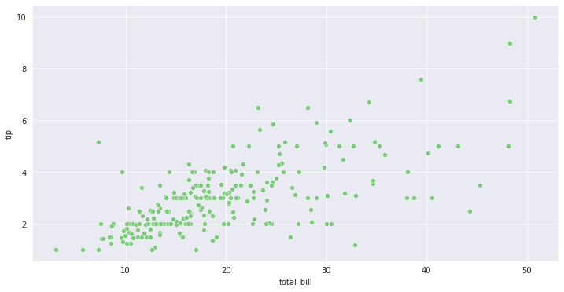

```python
graphic = sns.scatterplot(x='total_bill', y='tip', data=dados)
graphic.figure.set_size_inches(12, 6)
```

### Porcentagem

Criação de uma nova coluna no DataFrame. Qual a porcentagem da gorjeta em relação ao valor total da conta.

```python
dados['percent'] = ((dados['tip']*100) / dados['total_bill']).round(2)
```

```python
dados.head()
```

|  | total_bill | tip | dessert | day | time | size | percent |
| --- | --- | --- | --- | --- | --- | --- | --- |
| 0 | 16.99 | 1.01 | No | Sun | Dinner | 2 | 5.94 |
| 1 | 10.34 | 1.66 | No | Sun | Dinner | 3 | 16.05 |
| 2 | 21.01 | 3.50 | No | Sun | Dinner | 3 | 16.66 |
| 3 | 23.68 | 3.31 | No | Sun | Dinner | 2 | 13.98 |
| 4 | 24.59 | 3.61 | No | Sun | Dinner | 4 | 14.68 |

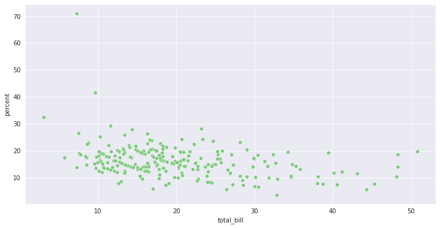

```python
graphic = sns.scatterplot(x='total_bill', y='percent', data=dados)
graphic.figure.set_size_inches(12, 6)
```

A função `relplot()` fornece acesso a duas funções de nível de eixos diferentes que mostram a relação entre duas variáveis com mapeamentos.

`scatterplot()` (kind="scatter"; padrão)

`lineplot()` (kind="line")

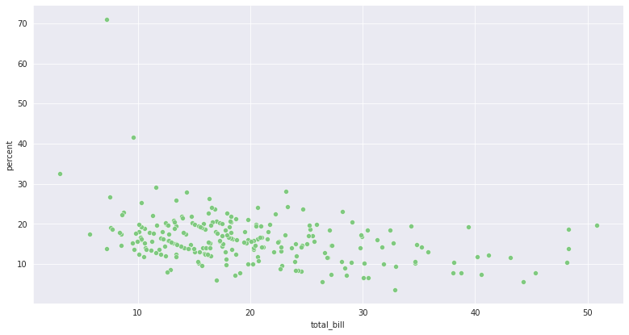

```python
graphic = sns.relplot(x='total_bill', y='percent', data=dados)
graphic.figure.set_size_inches(12, 6)
```

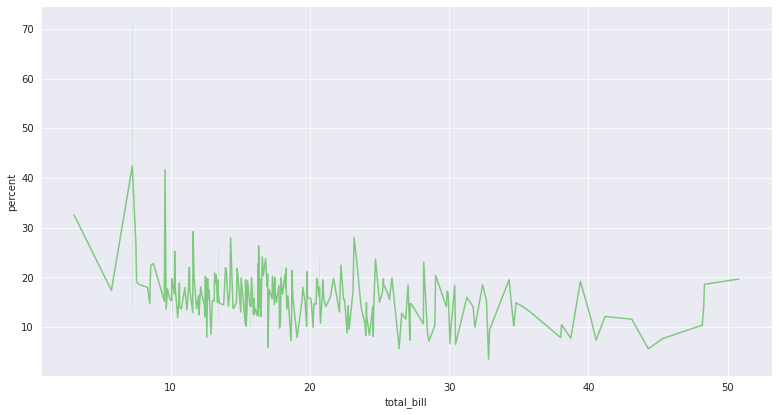

```python
graphic = sns.relplot(x='total_bill', y='percent', data=dados, kind='line')
graphic.figure.set_size_inches(12, 6)
```

Para deixar mais informativo o grafico, existem funções para isso.

`set_title('titulo', fontsize=18)`

`set_xlabel('descrição eixo x', fontsize=14)`

`set_ylabel('descrição eixo y', fontsize=14)`

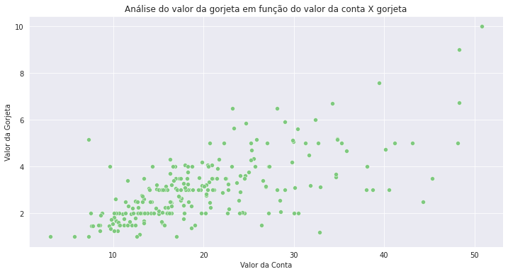

```python
graphic = sns.scatterplot(x='total_bill', y='tip', data=dados)
graphic.figure.set_size_inches(12, 6)
graphic.set_title('Análise do valor da gorjeta em função do valor da conta X gorjeta')
graphic.set_xlabel('Valor da Conta')
graphic.set_ylabel('Valor da Gorjeta')
graphic = graphic
```

# Análise 2 - Sobremesa

A função `catplot()` fornece acesso a várias funções em nível de eixo que mostram a relação entre uma variável numérica e uma ou mais variáveis categóricas usando uma das várias representações visuais.

`stripplot()` (kind="strip")

`swarmplot()` (kind="swarm")

`boxplot()` (kind="box")

`violinplot()` (kind="violin")

`boxenplot()` (kind="boxen")

`pointplot()` (kind="point")

`barplot()` (kind="bar")

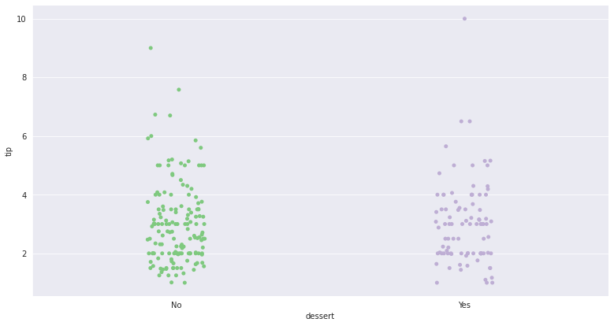

```python
graphic = sns.catplot(x='dessert', y='tip', data=dados)
graphic.figure.set_size_inches(12, 6)
```

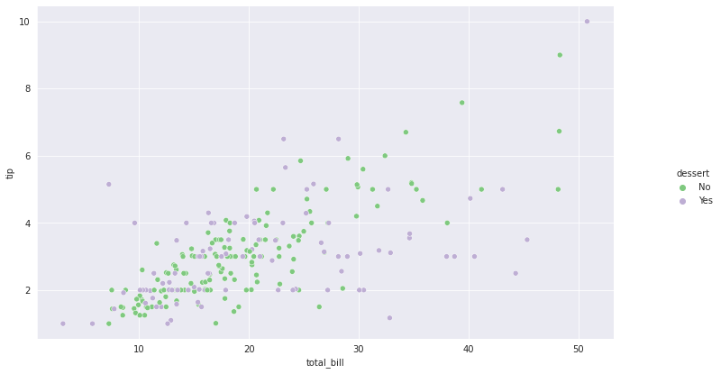

```python
graphic = sns.relplot(x='total_bill', y='tip', hue='dessert', data=dados)
graphic.figure.set_size_inches(12, 6)
```

A variavel *col* define subconjuntos para plotar em diferentes facetas.

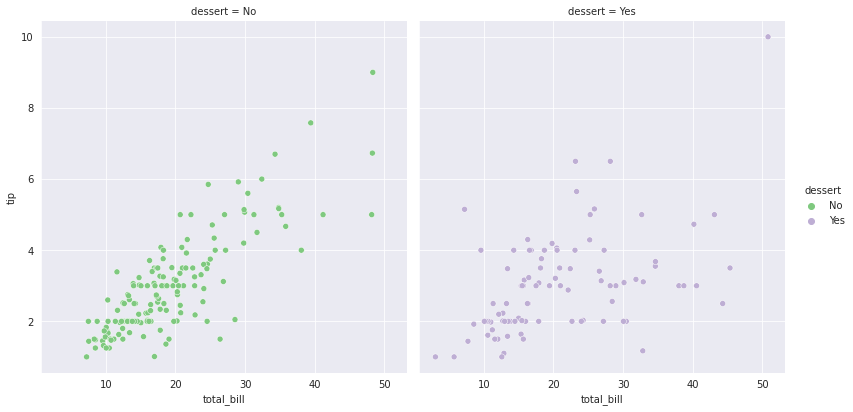

```python
graphic = sns.relplot(x='total_bill', y='tip', hue='dessert', col='dessert', data=dados)
graphic.figure.set_size_inches(12, 6)
```

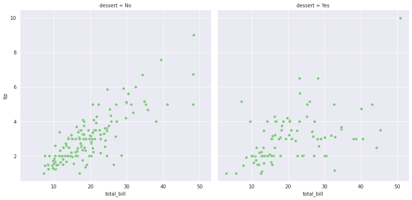

```python
graphic = sns.relplot(x='total_bill', y='tip', col='dessert', data=dados)
graphic.figure.set_size_inches(12, 6)
```

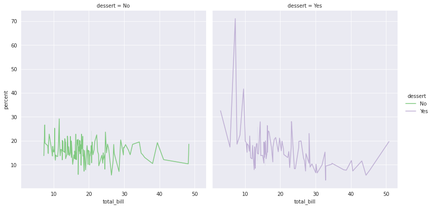

```python
graphic = sns.relplot(x='total_bill', y='percent', hue='dessert', col='dessert', kind='line', data=dados)
graphic.figure.set_size_inches(12, 6)
```

# Análise 3 - Dia da Semana

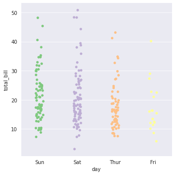

```python
sns.catplot(x='day', y='total_bill', data=dados)
```

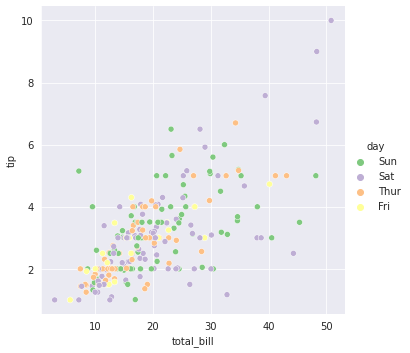

```python
sns.relplot(x='total_bill', y='tip', hue='day', data=dados)
```

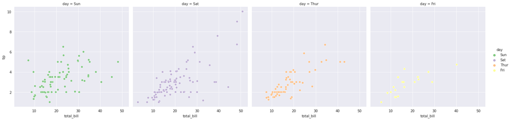

```python
sns.relplot(x='total_bill', y='tip', hue='day', col='day', data=dados)
```

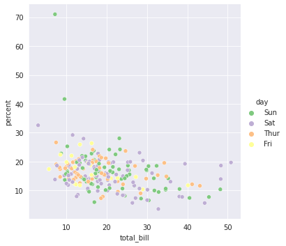

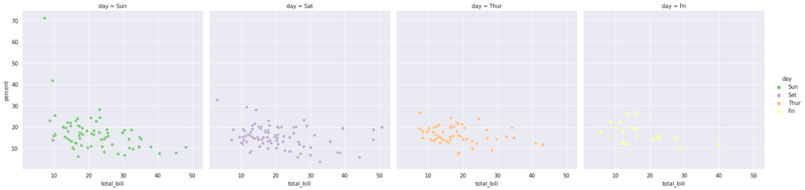

```python
sns.relplot(x='total_bill', y='percent', hue='day', data=dados)
sns.relplot(x='total_bill', y='percent', hue='day', col='day', data=dados)
```

# Análise 4 - Hora do Dia

```python
dados.head()
```

|  | total_bill | tip | dessert | day | time | size | percent |
| --- | --- | --- | --- | --- | --- | --- | --- |
| 0 | 16.99 | 1.01 | No | Sun | Dinner | 2 | 5.94 |
| 1 | 10.34 | 1.66 | No | Sun | Dinner | 3 | 16.05 |
| 2 | 21.01 | 3.50 | No | Sun | Dinner | 3 | 16.66 |
| 3 | 23.68 | 3.31 | No | Sun | Dinner | 2 | 13.98 |
| 4 | 24.59 | 3.61 | No | Sun | Dinner | 4 | 14.68 |

```python
dados.time.unique()
```

```
array(['Dinner', 'Lunch'], dtype=object)
```

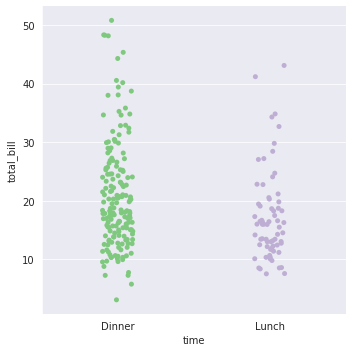

```python
sns.catplot(x='time', y='total_bill', data=dados)
```

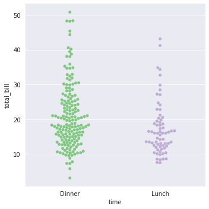

```python
sns.catplot(x='time', y='total_bill', kind='swarm', data=dados)
```

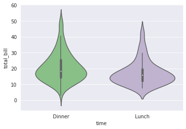

```python
sns.violinplot(x='time', y='total_bill', data=dados)
```

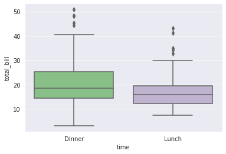

```python
sns.boxplot(x='time', y='total_bill', data=dados)
```

# LinePlot

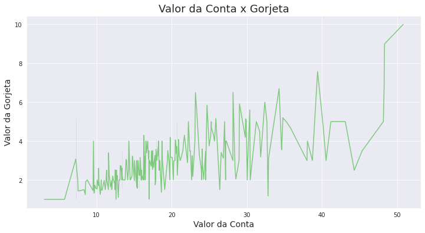

```python
graphic = sns.lineplot(x='total_bill', y='tip', data=dados)
graphic.figure.set_size_inches(12, 6)
graphic.set_title('Valor da Conta x Gorjeta', fontsize=18)
graphic.set_xlabel('Valor da Conta', fontsize=14)
graphic.set_ylabel('Valor da Gorjeta', fontsize=14)


graphic=graphic
```